# K-Means Clustering Analysis of U.S. States

Joshua Zhong

7/30/2024

# 1 Introduction

This analysis investigates how clustering techniques can be used to group U.S. states with similar socioeconomic characteristics using K-means clustering and Principal Component Analysis (PCA). Specifically, we explore how scaling and dimensionality reduction impact clustering results and seek to uncover meaningful patterns among the states.

The primary objectives of this analysis are:

- To explore the use of K-means clustering to identify patterns within the dataset.
- To assess the effect of scaling on clustering results.
- To determine the optimal number of clusters using the elbow method.
- To use PCA for dimensionality reduction and examine the impact on clustering results.
- To compare the clustering results before and after applying PCA to evaluate the benefits of dimensionality reduction.

Our objectives are to apply K-means clustering both before and after PCA and to assess whether dimensionality reduction enhances cluster interpretation.

## 1.1 Research Questions

- Can K-means clustering effectively group states with similar socioeconomic profiles?
- How does scaling affect the clustering outcomes?
- What is the optimal number of clusters, and how can we determine it using the elbow method?
- How does dimensionality reduction using PCA impact clustering results?
- How do the clustering results differ before and after applying PCA, and does PCA improve the clarity of the clusters?

# 2 Data Description

The dataset contains 51 observations (50 U.S. states plus the District of Columbia) with 31 numerical variables representing various socioeconomic indicators such as:

- Population count
- Employment rates
- Race distributions
- Income levels
- Educational attainment

Each observation represents a U.S. state or district, with the goal of identifying clusters of states with similar socioeconomic profiles.

```r
# Separate state names from the numerical data
state <- acs$State
data <- select(acs, -State)

str(data)
```

```
## 'data.frame':    51 obs. of  31 variables:
##  $ TotalPop        : int  4850771 738565 6809946 2977944 38982847 5436519 3594478 943732 672391 20278447 ...
##  $ Men             : num  0.485 0.523 0.497 0.491 0.497 ...
##  $ Women           : num  0.515 0.477 0.503 0.509 0.503 ...
##  $ VotingAgeCitizen: num  0.753 0.718 0.689 0.733 0.641 ...
##  $ MeanCommute     : num  24.7 19.2 25.3 21.7 28.9 ...
##  $ Employed        : num  0.424 0.479 0.434 0.429 0.462 ...
##  $ Hispanic_       : num  0.0409 0.068 0.3089 0.0716 0.3875 ...
##  $ White_          : num  0.659 0.615 0.556 0.73 0.379 ...
##  $ Black_          : num  0.2641 0.0306 0.0405 0.1535 0.0554 ...
##  $ Native_         : num  0.00466 0.13768 0.03915 0.0057 0.00353 ...
##  $ Asian_          : num  0.0128 0.0606 0.0304 0.0141 0.1392 ...
##  $ Pacific_        : num  0.0003 0.01191 0.00176 0.00234 0.00355 ...
##  $ Poverty_        : num  0.182 0.102 0.172 0.184 0.152 ...
##  $ ChildPoverty_   : num  0.257 0.135 0.228 0.254 0.19 ...
```

[output cut: 17 more lines]

The link to the raw CSV file is posted on GitHub: https://raw.githubusercontent.com/JZhong01/STA419/refs/heads/main/HW4data.csv.

# 3 Exploratory Data Analysis

## 3.1 Descriptive Statistics

```r
summary(acs)
```

```
##     State              TotalPop             Men             Women
##  Length:51          Min.   :  583200   Min.   :0.4745   Min.   :0.4769
##  Class :character   1st Qu.: 1747109   1st Qu.:0.4880   1st Qu.:0.5023
##  Mode  :character   Median : 4424376   Median :0.4926   Median :0.5074
##                     Mean   : 6294204   Mean   :0.4939   Mean   :0.5061
##                     3rd Qu.: 6989956   3rd Qu.:0.4977   3rd Qu.:0.5120
##                     Max.   :38982847   Max.   :0.5231   Max.   :0.5255
##  VotingAgeCitizen  MeanCommute       Employed        Hispanic_
##  Min.   :0.6387   Min.   :17.02   Min.   :0.4067   Min.   :0.01470
##  1st Qu.:0.7107   1st Qu.:22.09   1st Qu.:0.4530   1st Qu.:0.04925
##  Median :0.7326   Median :24.47   Median :0.4727   Median :0.09100
##  Mean   :0.7276   Mean   :24.42   Mean   :0.4761   Mean   :0.11549
##  3rd Qu.:0.7499   3rd Qu.:26.89   3rd Qu.:0.5028   3rd Qu.:0.13164
##  Max.   :0.7932   Max.   :33.18   Max.   :0.5372   Max.   :0.48162
##      White_           Black_            Native_             Asian_
##  Min.   :0.2223   Min.   :0.003934   Min.   :0.001035   Min.   :0.007058
##  1st Qu.:0.5801   1st Qu.:0.031982   1st Qu.:0.001883   1st Qu.:0.014991
##  Median :0.7294   Median :0.071573   Median :0.003747   Median :0.026313
##  Mean   :0.6883   Mean   :0.109599   Mean   :0.014371   Mean   :0.040512
##  3rd Qu.:0.8030   3rd Qu.:0.148553   3rd Qu.:0.009045   3rd Qu.:0.043858
##  Max.   :0.9359   Max.   :0.468723   Max.   :0.137682   Max.   :0.370140
##     Pacific_            Poverty_       ChildPoverty_    Professional_
##  Min.   :0.0001748   Min.   :0.08447   Min.   :0.1011   Min.   :0.2803
##  1st Qu.:0.0002630   1st Qu.:0.11634   1st Qu.:0.1464   1st Qu.:0.3390
##  Median :0.0004604   Median :0.14299   Median :0.1808   Median :0.3572
##  Mean   :0.0030655   Mean   :0.14300   Mean   :0.1847   Mean   :0.3643
##  3rd Qu.:0.0009063   3rd Qu.:0.16396   3rd Qu.:0.2193   3rd Qu.:0.3816
##  Max.   :0.0924273   Max.   :0.21794   Max.   :0.2941   Max.   :0.5713
##     Service_         Office_       Construction_      Production_
##  Min.   :0.1539   Min.   :0.1819   Min.   :0.03036   Min.   :0.04304
##  1st Qu.:0.1720   1st Qu.:0.2262   1st Qu.:0.08543   1st Qu.:0.10541
##  Median :0.1782   Median :0.2324   Median :0.09499   Median :0.12534
##  Mean   :0.1823   Mean   :0.2323   Mean   :0.09562   Mean   :0.12549
##  3rd Qu.:0.1843   3rd Qu.:0.2373   3rd Qu.:0.10807   3rd Qu.:0.13928
##  Max.   :0.2704   Max.   :0.2671   Max.   :0.15443   Max.   :0.19010
##      Drive_          Carpool_          Transit_            Walk_
##  Min.   :0.3616   Min.   :0.05774   Min.   :0.003628   Min.   :0.01232
##  1st Qu.:0.7557   1st Qu.:0.08731   1st Qu.:0.008064   1st Qu.:0.02064
##  Median :0.7926   Median :0.09261   Median :0.015951   Median :0.02674
##  Mean   :0.7718   Mean   :0.09378   Mean   :0.037726   Mean   :0.03122
##  3rd Qu.:0.8173   3rd Qu.:0.10098   3rd Qu.:0.037896   3rd Qu.:0.03759
##  Max.   :0.8552   Max.   :0.13698   Max.   :0.354092   Max.   :0.11644
##   OtherTransp_      WorkAtHome_       PrivateWork_     PublicWork_
##  Min.   :0.01052   Min.   :0.02146   Min.   :0.6687   Min.   :0.1048
##  1st Qu.:0.01350   1st Qu.:0.03931   1st Qu.:0.7672   1st Qu.:0.1306
##  Median :0.01621   Median :0.04580   Median :0.7916   Median :0.1454
##  Mean   :0.01857   Mean   :0.04687   Mean   :0.7852   Mean   :0.1531
##  3rd Qu.:0.01967   3rd Qu.:0.05434   3rd Qu.:0.8161   3rd Qu.:0.1625
##  Max.   :0.06114   Max.   :0.07274   Max.   :0.8464   Max.   :0.2672
##  SelfEmployed_      FamilyWork_        Unemployment_     income_weighted
##  Min.   :0.03953   Min.   :0.0008711   Min.   :0.02783   Min.   :22500
##  1st Qu.:0.05095   1st Qu.:0.0014585   1st Qu.:0.05278   1st Qu.:27634
##  Median :0.05840   Median :0.0016907   Median :0.06465   Median :29866
##  Mean   :0.05985   Mean   :0.0017881   Mean   :0.06337   Mean   :31006
##  3rd Qu.:0.06507   3rd Qu.:0.0019031   3rd Qu.:0.07405   3rd Qu.:33786
##  Max.   :0.08904   Max.   :0.0041909   Max.   :0.09242   Max.   :50832
```

By the nature of the data, certain variables are expected to be correlated, particularly those related to demographics and socioeconomic factors. For example:

- **Race and ethnicity** variables like White, Black, Asian, and Native populations are often correlated because they represent proportions of a whole (the total population), meaning an increase in one category generally implies a decrease in another.
- **Employment, commute, and transportation** variables may exhibit correlations due to underlying socioeconomic and geographic factors.
- **Income and poverty** are often inversely correlated with socioeconomic indicators like child poverty rates.

As a result of these inherent correlations amongst these categories, applying dimensionality reduction using PCA would be valuable in simplifying the data, reducing redundancy, and focusing on key underlying patterns.

# 4 Methods

## 4.1 K-Means Clustering

K-means clustering is an unsupervised learning technique that groups data points into K clusters based on feature similarity. The algorithm assigns points to clusters by minimizing the within-cluster sum of squares (WSS). We will apply K-means clustering both on the original scaled data and on the principal components obtained after PCA.

### 4.1.1 Rationale for Using K-Means:

- **Unsupervised Learning**: K-means helps identify patterns without labels.
- **Partitioning States into Groups**: This method will help identify patterns in U.S. states based on socioeconomic indicators.
- **Evaluation**: We will use metrics like the elbow plot, silhouette score, and WSS to determine the optimal number of clusters and evaluate cluster quality.

## 4.2 Principal Component Analysis (PCA)

Principal Component Analysis (PCA) is applied to the scaled data to reduce its dimensionality and make clustering more efficient. In high-dimensional data, clustering methods like K-means can become less effective due to the “curse of dimensionality,” where the distance between data points becomes less informative. PCA helps overcome this challenge by transforming the data into a smaller number of uncorrelated components that explain most of the variance in the dataset.

### 4.2.1 Rationale for Using PCA

- **Dimensionality Reduction**: PCA simplifies the dataset by focusing on the most important components.
- **Improving Clustering**: By reducing dimensionality, PCA improves clustering since clustering becomes less effective with high-dimensional data.

# 5 Performing PCA on Clusters

## 5.1 Pre-PCA K-Means Clustering on Original Scaled Data

We first applied K-means clustering to the original scaled data. Below are the results:

### 5.1.1 K-means on Raw Data (k = 2)

```r
#Ensure same clusters generated
set.seed(123)

# Perform K-means with k = 2
km.2 <- kmeans(data, centers = 2, nstart = 20)

# Display number of states in each cluster
clusters <- as.character(km.2$cluster)
table(clusters)
## clusters
##  1  2
##  4 47
```

K-means with k=2 clusters resulted in clusters of size 4 and 47.

```r
km.out <- data.frame(state, clusters)
  filter(km.out, clusters == "1")
```

```
##        state clusters
## 1 California        1
## 2    Florida        1
## 3   New York        1
## 4      Texas        1
```

Examining these further, we find that Cluster 1 composes of California, Texas, New York, and Florida - these happen to be the states with the 4 largest population sizes.

This is likely the result of a disparity between the variances and distributions of the variables. There is also a discrepancy in certain units of measurement: the TotalPop variable is the actual population of the state, whereas income_weighted is the per-capita income. The remaining variables are also proportions. Since K-means clustering relies on Euclidean distances, we want each of the variables to be on similar scales.

### 5.1.2 K-Means on Scaled Data (k = 2)

Since K-means is sensitive to the scale of the variables, we now scale the data and re-examine the result generated from K-means clustering with k=2.

```r
set.seed(123)

# Scale the data
data.sc <- scale(data)

# Perform K-means with k = 2 on scaled data
km.2.sc <- kmeans(data.sc, centers = 2, nstart = 20)
table(km.2.sc$cluster)
```

```
##
##  1  2
## 32 19
```

### 5.1.3 Optimal Number of Clusters

We evaluate different values of k using an elbow plot to determine the optimal number of clusters. The elbow plot displays the within-cluster sum of squares (WSS) for different values of k. As k increases, WSS decreases, but the rate of improvement slows down after a certain point. This “elbow” in the plot indicates the optimal number of clusters, where adding more clusters provides diminishing returns in terms of explaining variance.

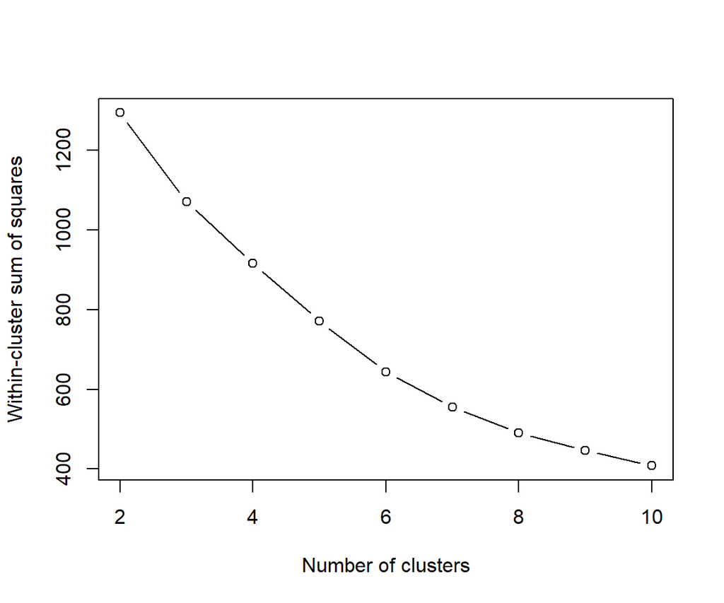

```r
# Elbow plot for K-means clustering
wss <- sapply(2:10, function(k) kmeans(data.sc, k, nstart = 20)$tot.withinss)
plot(2:10, wss, type = "b", xlab = "Number of clusters", ylab = "Within-cluster sum of squares")
```

In this analysis, k = 8 was selected because it offers the best trade-off between reducing WSS and maintaining a reasonable number of clusters for interpretation.

## 5.2 Post-PCA K-Means Clustering

After applying PCA to reduce the dimensionality of the dataset, we reapplied K-means clustering on the principal components. The goal was to assess whether PCA would improve the clarity of the clusters.

### 5.2.1 PCA on Scaled Data

We applied PCA to the scaled data, reducing the dataset’s dimensionality:

```r
# Perform PCA with scaling
pca <- prcomp(data, scale = TRUE)
summary(pca)
## Importance of components:
##                           PC1    PC2    PC3    PC4     PC5    PC6     PC7
## Standard deviation     2.7305 2.6108 2.2165 1.8331 1.39835 1.0981 1.02592
## Proportion of Variance 0.2405 0.2199 0.1585 0.1084 0.06308 0.0389 0.03395
## Cumulative Proportion  0.2405 0.4604 0.6189 0.7273 0.79034 0.8292 0.86319
##                            PC8     PC9    PC10    PC11    PC12    PC13    PC14
## Standard deviation     0.95189 0.83542 0.71417 0.64627 0.62422 0.59567 0.50603
## Proportion of Variance 0.02923 0.02251 0.01645 0.01347 0.01257 0.01145 0.00826
## Cumulative Proportion  0.89242 0.91493 0.93139 0.94486 0.95743 0.96887 0.97713
##                           PC15   PC16    PC17    PC18    PC19    PC20    PC21
## Standard deviation     0.41380 0.3431 0.32286 0.31120 0.25988 0.21717 0.18538
## Proportion of Variance 0.00552 0.0038 0.00336 0.00312 0.00218 0.00152 0.00111
## Cumulative Proportion  0.98266 0.9865 0.98982 0.99294 0.99512 0.99664 0.99775
##                           PC22   PC23    PC24    PC25    PC26    PC27      PC28
## Standard deviation     0.16042 0.1369 0.10672 0.08802 0.07514 0.02153 0.0003769
## Proportion of Variance 0.00083 0.0006 0.00037 0.00025 0.00018 0.00001 0.0000000
## Cumulative Proportion  0.99858 0.9992 0.99955 0.99980 0.99999 1.00000 1.0000000
##                             PC29      PC30      PC31
## Standard deviation     0.0002105 0.0001032 5.428e-15
## Proportion of Variance 0.0000000 0.0000000 0.000e+00
## Cumulative Proportion  1.0000000 1.0000000 1.000e+00
```

The first six principal components (PCs) explain approximately 82.92% of the total variance, meaning that these six PCs capture the majority of the variation present in the original dataset. This allows us to reduce the dataset from over 30 dimensions to a more manageable number, making it easier to apply K-means clustering.

### 5.2.2 K-Means on PCA-Reduced Data (k = 8)

```r
# K-means clustering on PCA-reduced data
set.seed(123)
km.pca <- kmeans(pca$x[, 1:6], centers = 8, nstart = 20)
table(km.pca$cluster)
```

```
##
##  1  2  3  4  5  6  7  8
##  6  1  1  1 10  6 15 11
```

## 5.3 Comparison of Pre- and Post-PCA Clustering

To assess the impact of PCA on clustering performance, we compared the K-means clustering results both before and after applying PCA using three key metrics: Within-cluster Sum of Squares (WSS), Between-cluster Sum of Squares (BSS), and Silhouette Scores.

### 5.3.1 Clustering Evaluation Metrics

1. **Within-Cluster Sum of Squares (WSS)**: This measures the compactness of clusters. A lower WSS indicates that the data points are closer to their respective cluster centers, implying tighter and more homogeneous clusters. However, it is essential to note that WSS alone is not always the best indicator of cluster quality since it doesn’t consider how distinct the clusters are from one another.
2. **Between-Cluster Sum of Squares (BSS)**: This measures the separation between clusters. A higher BSS suggests that the clusters are more distinct from each other. Ideally, we want the ratio of BSS to total sum of squares (TSS) to be high, meaning the between-cluster variance explains a large proportion of the total variance.
3. **Silhouette Scores**: The silhouette score evaluates both cluster compactness and separation. It ranges from -1 to 1, where a higher score indicates better clustering. A score close to 1 implies that data points are well matched to their own cluster and poorly matched to neighboring clusters. A negative silhouette score suggests points are potentially misclassified.

### 5.3.2 Key Findings

We calculated the WSS, BSS, and silhouette scores for both the pre- and post-PCA clusters to assess the clustering quality.

```r
# K-means clustering on scaled data with k = 8
set.seed(123)

# Perform K-means with k = 8 on scaled data (pre-PCA)
km.8.sc <- kmeans(data.sc, centers = 8, nstart = 20)


# WSS and BSS for pre-PCA and post-PCA clustering
wss_pre <- sum(km.8.sc$withinss)
wss_post <- sum(km.pca$withinss)
bss_pre <- km.8.sc$betweenss
bss_post <- km.pca$betweenss

# Silhouette scores
sil_pre <- silhouette(km.8.sc$cluster, dist(data.sc))
sil_post <- silhouette(km.pca$cluster, dist(pca$x[, 1:6]))

# Create comparison table
comparison <- data.frame(
  Method = c("Pre-PCA", "Post-PCA"),
  WSS = c(wss_pre, wss_post),
  BSS = c(bss_pre, bss_post),
  Silhouette = c(mean(sil_pre[, 3]), mean(sil_post[, 3]))
)

kable(comparison, caption = "Comparison of Clustering Metrics: Pre- and Post-PCA")
```

Comparison of Clustering Metrics: Pre- and Post-PCA

| Method | WSS | BSS | Silhouette |
| --- | --- | --- | --- |
| Pre-PCA | 490.2326 | 1059.767 | 0.2277797 |
| Post-PCA | 270.3395 | 1014.981 | 0.3135851 |

The comparison of clustering metrics before and after applying PCA reveals some significant insights:

- Within-Cluster Sum of Squares (WSS): The WSS, which measures how tightly grouped the points are within their respective clusters, decreased from 490.23 (Pre-PCA) to 270.34 (Post-PCA). This reduction in WSS indicates that the clusters became more compact and cohesive after applying PCA. By focusing on the most informative principal components, PCA reduces noise and irrelevant variability, resulting in tighter clusters.
- Between-Cluster Sum of Squares (BSS): The BSS, which indicates the separation between clusters, slightly decreased from 1059.77 (Pre-PCA) to 1014.98 (Post-PCA). This reduction suggests that the overall separation between clusters diminished somewhat after PCA. However, this is likely because PCA removed noise and less informative dimensions, reducing variability that may have artificially increased cluster separation. The increase in silhouette scores post-PCA confirms that the compactness and overall quality of the clusters improved, even with the slight trade-off in separation.
- Silhouette Scores: The silhouette score improved from 0.23 (Pre-PCA) to 0.31 (Post-PCA). Silhouette scores consider both compactness and separation of clusters. The improvement suggests that although the BSS decreased slightly, the overall cluster quality increased due to better-defined clusters with clearer boundaries. This indicates that PCA helped produce more meaningful and distinct groupings of the states.

### 5.3.3 Visualization of Clusters

To better understand the cluster composition, we first examine which states belong to which clusters, both before and after PCA.

```r
# Pre-PCA cluster assignments (k = 8)
km.out.pre <- data.frame(state = state, Cluster = km.8.sc$cluster)

# Post-PCA cluster assignments (k = 8)
km.out.post <- data.frame(state = state, Cluster = km.pca$cluster)

# Create a consolidated table for Pre-PCA clustering assignments (k = 8)
pre_pca_clusters <- km.out.pre %>%
  group_by(Cluster) %>%
  summarise(States = paste(state, collapse = ", "))

# Create a consolidated table for Post-PCA clustering assignments (k = 8)
post_pca_clusters <- km.out.post %>%
  group_by(Cluster) %>%
  summarise(States = paste(state, collapse = ", "))

# Display both tables side by side for comparison
pre_pca_clusters_table <- pre_pca_clusters %>%
  rename("Pre-PCA Cluster" = Cluster, "States in Cluster" = States)

post_pca_clusters_table <- post_pca_clusters %>%
  rename("Post-PCA Cluster" = Cluster, "States in Cluster" = States)

# Combine the two tables side by side
combined_clusters <- cbind(pre_pca_clusters_table, post_pca_clusters_table)

# Show the table
knitr::kable(combined_clusters, caption = "Comparison of Pre- and Post-PCA Cluster Assignments")
```

Comparison of Pre- and Post-PCA Cluster Assignments

| Pre-PCA Cluster | States in Cluster | Post-PCA Cluster | States in Cluster |
| --- | --- | --- | --- |
| 1 | Montana, North Dakota, South Dakota, Wyoming | 1 | Idaho, Montana, North Dakota, South Dakota, Vermont, Wyoming |
| 2 | District of Columbia | 2 | District of Columbia |
| 3 | Hawaii | 3 | Hawaii |
| 4 | Alaska | 4 | Alaska |
| 5 | Connecticut, Delaware, Illinois, Maryland, Massachusetts, New Jersey, New York, Pennsylvania, Rhode Island, Virginia | 5 | Connecticut, Delaware, Illinois, Maryland, Massachusetts, New Jersey, New York, Pennsylvania, Rhode Island, Virginia |
| 6 | Arizona, California, Florida, Nevada, New Mexico, Texas | 6 | Arizona, California, Florida, Nevada, New Mexico, Texas |
| 7 | Alabama, Arkansas, Georgia, Indiana, Kentucky, Louisiana, Michigan, Mississippi, Missouri, North Carolina, Ohio, Oklahoma, South Carolina, Tennessee, West Virginia | 7 | Alabama, Arkansas, Georgia, Indiana, Kentucky, Louisiana, Michigan, Mississippi, Missouri, North Carolina, Ohio, Oklahoma, South Carolina, Tennessee, West Virginia |
| 8 | Colorado, Idaho, Iowa, Kansas, Maine, Minnesota, Nebraska, New Hampshire, Oregon, Utah, Vermont, Washington, Wisconsin | 8 | Colorado, Iowa, Kansas, Maine, Minnesota, Nebraska, New Hampshire, Oregon, Utah, Washington, Wisconsin |

To visualize the clusters geographically, we can create a map of the United States, coloring the states based on their assigned clusters. This will help us identify any geographical patterns in the clustering, showing how states with similar socioeconomic profiles are grouped together.

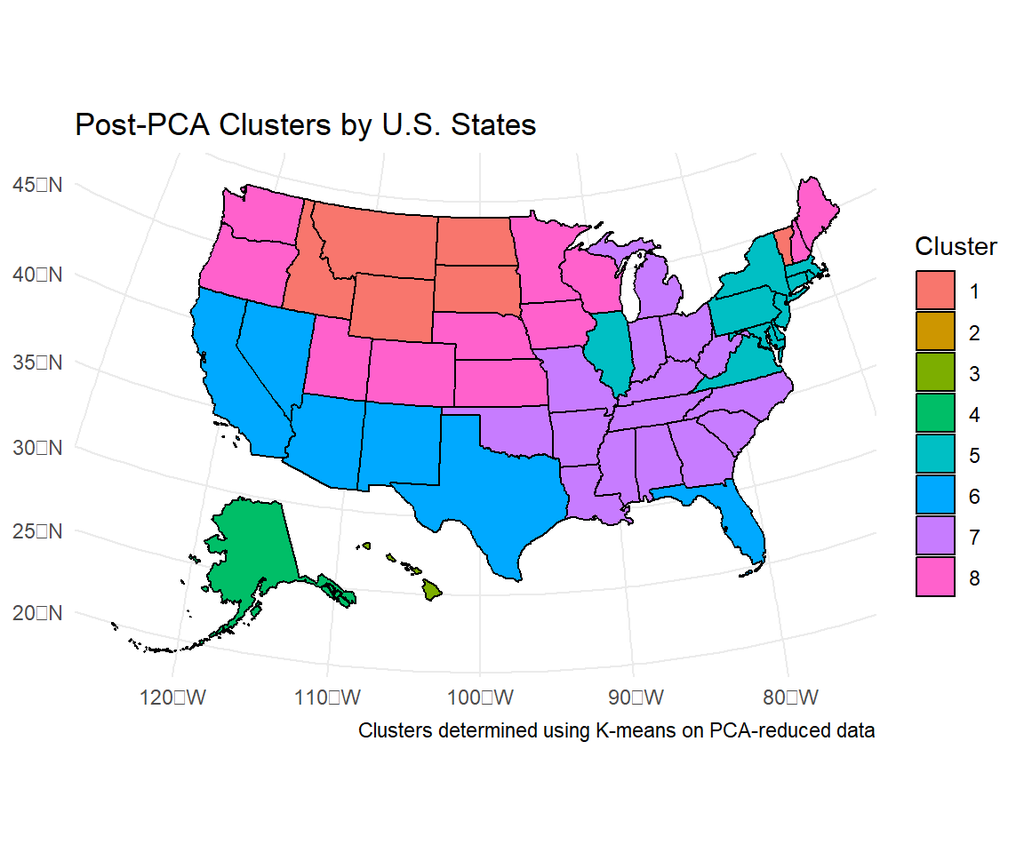

```r
# Convert cluster assignments to factor
cluster_map_data <- data.frame(state = km.out.post$state,
                               cluster = as.factor(km.out.post$Cluster))

# Plot U.S. map with states colored by cluster (Post-PCA)
plot_usmap(data = cluster_map_data, values = "cluster", color = "black") +
  scale_fill_discrete(name = "Cluster") +
  labs(title = "Post-PCA Clusters by U.S. States",
       caption = "Clusters determined using K-means on PCA-reduced data") +
  theme_minimal() +   # Use theme_minimal to avoid issues with legend elements
  theme(legend.position = "right")
```

# 6 Results and Interpretation

This section provides a detailed interpretation of the clustering results after PCA, along with comparisons to the pre-PCA scenario. We focus on the composition of each cluster and explain how PCA affected the grouping of U.S. states based on their socioeconomic characteristics.

## 6.2 Interpretation of Post-PCA Clusters

Cluster 1:

- States: Idaho, Montana, North Dakota, South Dakota, Vermont, Wyoming
- Key Characteristics: Sparsely populated, rural states with lower population density and relatively homogeneous socioeconomic structures.

Cluster 2:

- States: District of Columbia
- Key Characteristics: D.C. remains unique due to its high population density, high per capita income, and the fact that it serves as the nation’s capital.

Cluster 3:

- States: Hawaii
- Key Characteristics: Hawaii’s isolation, reliance on tourism, and distinct economy and geography explain its separation from the mainland states.

Cluster 4:

- States: Alaska
- Key Characteristics: Alaska is similar to Hawaii in that it is geographically and economically isolated, with a low population density and a resource-based economy.

Cluster 5:

- States: Connecticut, Delaware, Illinois, Maryland, Massachusetts, New Jersey, New York, Pennsylvania, Rhode Island, Virginia
- Key Characteristics: Primarily Northeastern states with high urbanization, higher income levels, and advanced infrastructures.

Cluster 6:

- States: Arizona, California, Florida, Nevada, New Mexico, Texas
- Key Characteristics: Large, populous states with diverse populations and strong economies. These states also share warm climates and significant Hispanic/Latino populations.

Cluster 7:

- States: Alabama, Arkansas, Georgia, Indiana, Kentucky, Louisiana, Michigan, Mississippi, Missouri, North Carolina, Ohio, Oklahoma, South Carolina, Tennessee, West Virginia.
- Key Characteristics: Southern and Midwestern states with lower income levels, higher poverty rates, and economies reliant on agriculture and manufacturing.

Cluster 8:

- States: Colorado, Iowa, Kansas, Maine, Minnesota, Nebraska, New Hampshire, Oregon, Utah, Washington, Wisconsin
- Key Characteristics: States with moderate populations, strong agricultural economies, and a mix of rural and urban areas.

## 6.3 Final Thoughts on Post-PCA Clusters

The post-PCA clusters provide a more coherent and interpretable grouping of U.S. states based on socioeconomic factors. The dimensionality reduction helped to remove noise and less relevant features, allowing for clearer distinctions between clusters. As a result, states with similar profiles are grouped together in ways that make intuitive sense based on their economic structures, demographics, and geographical locations.

# 7 Conclusion

In this report, we explored the use of K-means clustering and Principal Component Analysis (PCA) to uncover socioeconomic groupings among U.S. states based on data from the 2017 American Community Survey (ACS). The key objectives were to compare clustering results before and after PCA and assess whether dimensionality reduction improved the clustering outcomes.

Our analysis showed that PCA significantly enhanced the performance of K-means clustering. By reducing the dimensionality of the dataset to the most informative principal components, we were able to remove noise and irrelevant variability, allowing for more compact and cohesive clusters. This improvement was evident in the reduced Within-Cluster Sum of Squares (WSS) and increased silhouette scores after PCA, suggesting that the clusters became both more compact and better defined.

The post-PCA clustering revealed several meaningful groupings of states. Notably, we identified clusters that aligned with both geographic regions (e.g., rural, sparsely populated Northern states) and economic characteristics (e.g., Southern and Midwestern states with lower income levels, or large, populous states with diverse populations and strong economies). This demonstrates how clustering and dimensionality reduction can help uncover patterns in socioeconomic data that are both intuitive and insightful.

In summary, the use of PCA greatly improved the interpretability and quality of the clusters generated through K-means. By focusing on the most important variables, we were able to reveal distinct groupings of U.S. states based on their socioeconomic characteristics. This type of analysis can be further expanded by incorporating additional data or applying alternative clustering techniques to gain deeper insights into the socioeconomic patterns that shape different regions of the United States.